# OefenignenexpLog

Jens Buysse

11/3/2020

## Oefeningen op exponentiële en logaritmische functies

### Illustratie

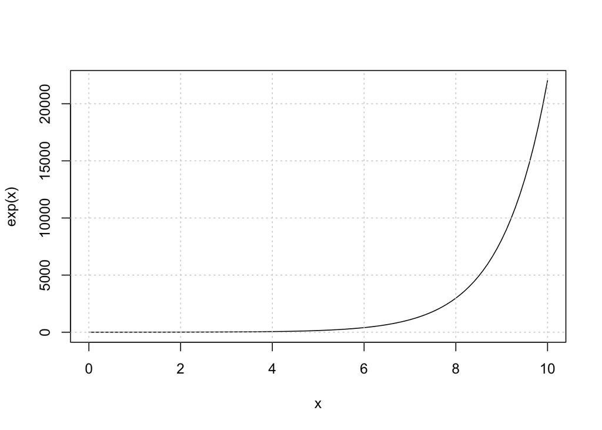

```r
curve(exp,0,10)
grid()
```

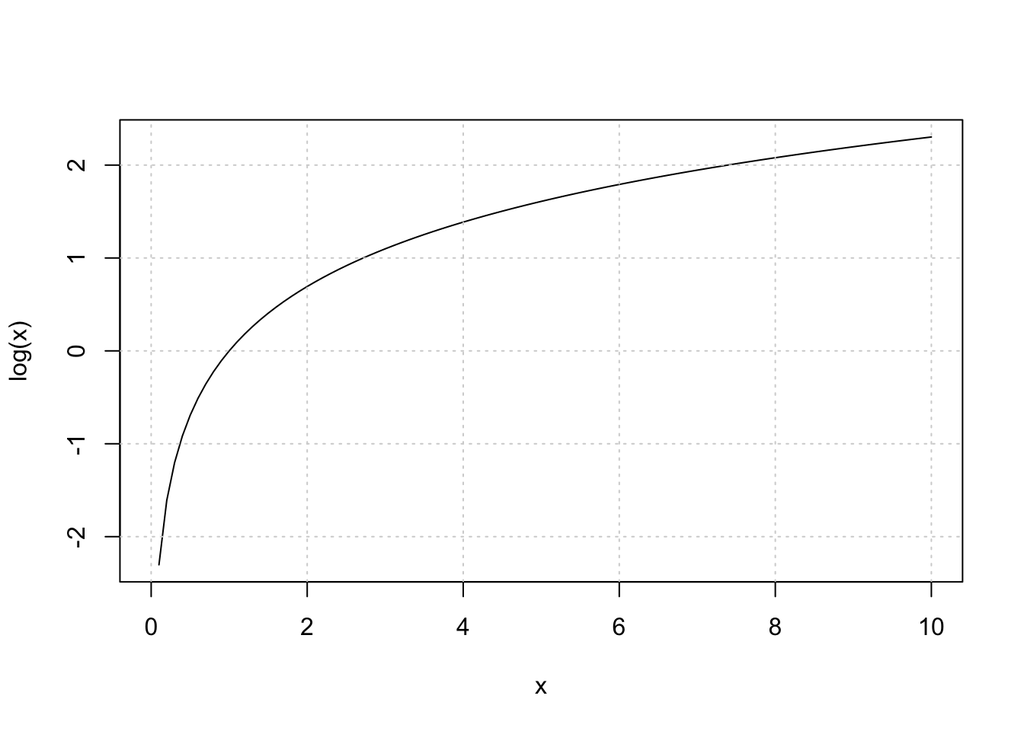

```r
curve(log,0,10)
grid()
```

### Oefeningen

- $log_5 5 = 1$ Kan je ook berekenen met R (voor code zie source file) 1
- $lg_{\frac{1}{2}} = -1$ of dus -1
- $log_{\sqrt{2}} 1 = 0$
- $\dots$

Los op naar $x$

- $log_9 = \frac{1}{2} \Leftrightarrow log_9 x = \frac{1}{2} \rightarrow x = 3$
- $lg(3x-1) + lg(2x+1) = lg(12) - lg(3) \Leftrightarrow lg(6x + 3x -2x -1) = lg(4) \Leftrightarrow lg(7x-1) = lg(4) \Leftrightarrow 7x -1 = 4 \Leftrightarrow x = \frac{5}{7}$

### Extra oefeningen

Bepaal het domein en beeld van $f$. Geef de nulpunten, het snijpuntmet de $Y$ as en eventuele asymptoten van $f$. Teken ten slotte de grafiek van $f$ en bepaal de gevraagde functiewaarde.

- $f : \mathbb(R) \rightarrow \mathbb(R) : x \rightarrow y = log_3 x)$
- domein van $f$ is $\mathbb(R)_0^+$
- beeld van $f$ is $\mathbb(R)$
- nulpunt $x=1$ want $log_3 x = 0 \Leftrightarrow x = 1$
- Snijpunt met de $y$-as is er niet want $O \notin$ domein van $f$
- Er is een verticale assymptoot, de rechte met vergelijking $x=0$ of dus de $y$-as. Dit valt buiten de scope van deze cursus, maar probeer zelf eens na te gaan of dit klopt.

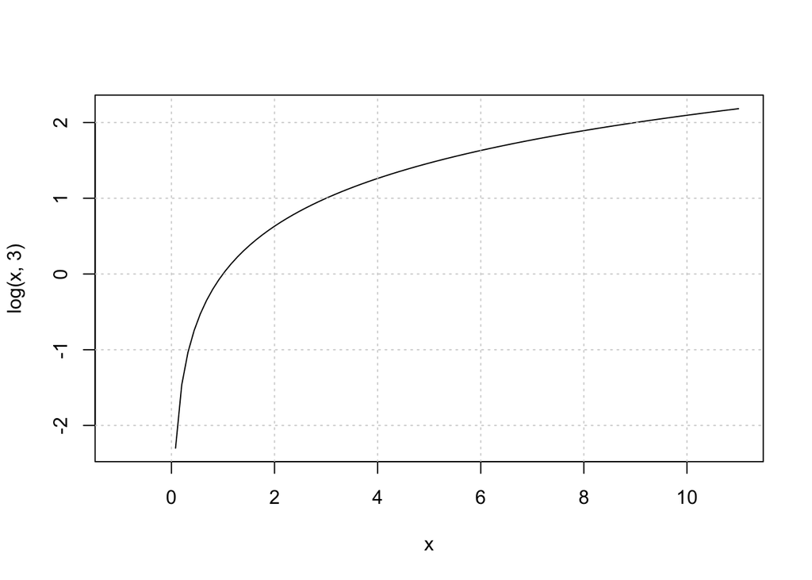

```r
curve(log(x,3),-1,11)
grid()
```

### Oefening Angry Birds

Je speelt het spel Angry Birds. Je moet door boze vogels te lanceren zoveelmogelijk groene varkens raken. Je krijgt hiervoor drie pogingen. Er bevinden zich groene varkens op de punten: $(1,4),(2,4),(2,5),(3,1),(3,3),(3,4),(3,5),(4,2),(4,4)$.

Je mag drie vogels lanceren: een bruine, rode en blauwe vogel.

We maken de tekening door de curves van de gegeven functies te tekenen.

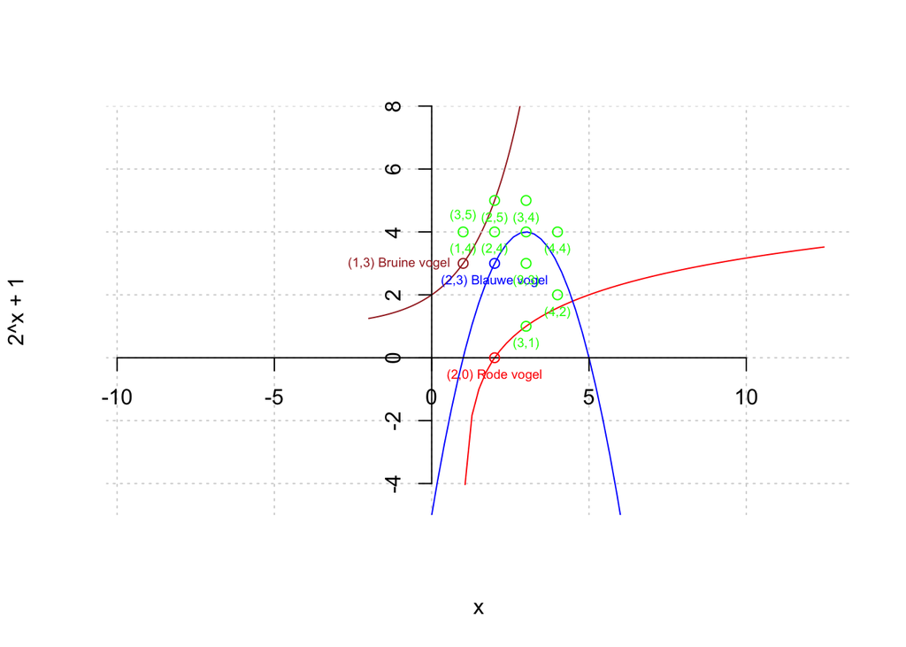

```r
curve(2^x+1,-2,5, col = "brown",xlim = c(-2,5), ylim=c(-5,8),axes=FALSE, asp=1, pty="s",xaxs="i",yaxs="i")
grid()
curve(log(x-1,2),col = "red", add = TRUE)
curve(-x^2 + 6*x -5, col="blue", add=TRUE)
axis(side = 1, pos=0)
axis(side=2, pos=0)

#Tekenen van de punten
points(1, 3, type = "p", col="brown")
text(1, 3, "(1,3) Bruine vogel", cex=0.6, pos=2, col="brown")

points(2, 0, type = "p", col="red")
text(2, 0, "(2,0) Rode vogel", cex=0.6, pos=1, col="red")

points(2, 3, type = "p", col="blue")
text(2, 3, "(2,3) Blauwe vogel", cex=0.6, pos=1, col="blue")

# Varkens tekenen
points(1, 4, type = "p", col="green")
text(1, 4, "(1,4)", cex=0.6, pos=1, col="green")

points(2, 4, type = "p", col="green")
text(2, 4, "(2,4)", cex=0.6, pos=1, col="green")

points(2, 5, type = "p", col="green")
text(2, 5, "(2,5)", cex=0.6, pos=1, col="green")

points(3, 1, type = "p", col="green")
text(3, 1, "(3,1)", cex=0.6, pos=1, col="green")

points(3, 3, type = "p", col="green")
text(3, 3, "(3,3)", cex=0.6, pos=1, col="green")

points(3, 4, type = "p", col="green")
text(3, 5, "(3,4)", cex=0.6, pos=1, col="green")

points(3, 5, type = "p", col="green")
text(1, 4, "(3,5)", cex=0.6, pos=3, col="green")

points(4, 2, type = "p", col="green")
text(4, 2, "(4,2)", cex=0.6, pos=1, col="green")

points(4, 4, type = "p", col="green")
text(4, 4, "(4,4)", cex=0.6, pos=1, col="green")
```

Een varken zal geraakt worden door een vogel, als je zijn coördinaten in de vergelijking van het traject van de vogel zet. Je kan al duidelijk zien op de tekening welke varkens door welke vogels geraakt zullen worden. Ga nu thuis na door de vergelijking op te lossen. Bv. ($f(2) = 2^2 + 1 = 5$ dus $(2,5)$ wordt geraakt door de bruine vogel.)

Er moeten nu extra varkens geraakt worden. Om het varken op $(4,2)$ te raken via een rechte lijn vanuit positie $(1,2)$ moet je een lineaire functie definiëren die deze twee punten bevat. Dat komt overeen met een rechte evenwijdig met de x-as, namelijk $y=2$.

Vaarken met coördinaten $(2,4)$: Hier moet je opnieuw een rechte definiëren. We hebben reeds gezien hoe we de vergelijking van een rechte bepalen, gegeven twee punten van die rechte. Je komt dan $y = 2x$ uit.

### Oefening op ceil en floor

Stel $f: \mathbb{R} \rightarrow \mathbb{R}: x \rightarrow floor(ceiling(x - \frac{1}{2}))$

- Bepaal het domein, beeld, grafiek en de nulpunten
- Domein : $\mathbb{R}$, de functie is overal gedefinieerd
- Beeld: $\mathbb{Z}$
- Nulpunten:

$$\begin{eqnarray}
floor(ceiling(x - \frac{1}{2})) = 0 & \Leftrightarrow 0 \leq ceiling(x - \frac{1}{2}) < 1 \\
\Leftrightarrow & ceiling(x - \frac{1}{2}) = 0 \\
\Leftrightarrow & -1< x - \frac{1}{2} \leq 0 \\
\Leftrightarrow & - \frac{1}{2} < x \leq \frac{1}{2}
\end{eqnarray}$$

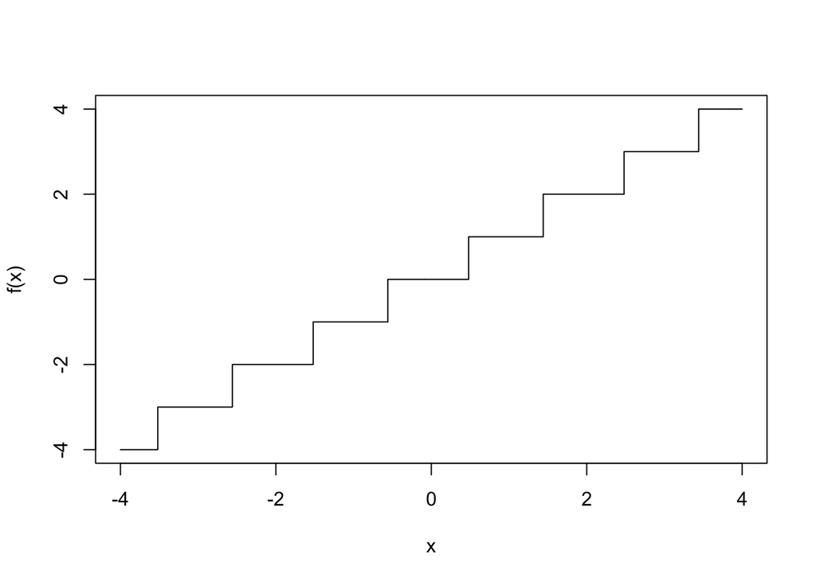

```r
f <- function(x){
  return(floor(ceiling(x-1/2)))
}

curve(f,-4,4,type = "S")
```

Let op dat bij deze grafiek de verticale lijnen er eigenlijk niet bij mogen getekend worden.